# Week 4 - Univariate Analysis, part 2

# 1. Lesson - None

# 2. Weekly graph question

Below are a histogram and boxplot representation of the same data. A pharmacy is keeping a record of the prices of the drugs that it sells, and an administrator wants to know how much the more expensive drugs tend to cost, in the context of the other prices.

Please write a short explanation of the pros and cons of these two representations. Which would you choose? How would you modify the formatting, if at all, to make it more visually interesting, clear, or informative?

```python
import numpy as np
import pandas as pd
import matplotlib.pyplot as plt
import seaborn as sns

np.random.seed(0)
num_data = 100
data = np.exp(np.random.uniform(size = num_data) * 4)
df = pd.DataFrame(data.T, columns = ["data"])
```

```
The 75th percentile is: data    15.457656
Name: 0.75, dtype: float64
```

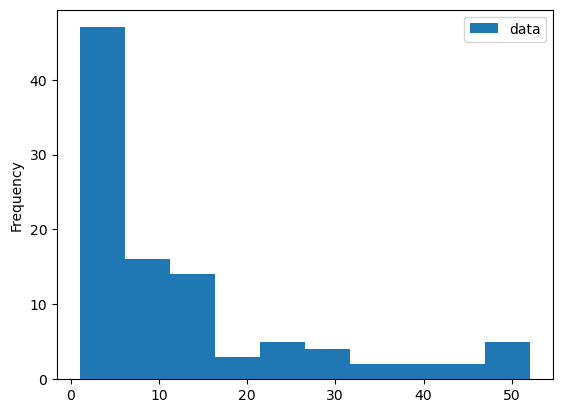

```python
print("The 75th percentile is:", df.quantile(q = 0.75))
df.plot.hist()
```

### Neither of the plots are easily consumable in that they do not have any contextual information (such as what the data actually is representing, what each axis represents, etc.).

**The Histogram**

- Pros:
1. The histogram is easily readable in that it is in a format we are more used to than others
- Cons:
1. The histogram is vertical making us do the eye zigzag instead of being horizontal, which would be easier to read
2. As in a previous example, the legend is next to useless in that all it says is that this is data
3. The y-axis label is similarly useless in that frequency has very little meaning in this context
4. There probably should be either more bins and/or more space between the bins

**The boxplot:**

- Pros:
1. One can more easily see outliers using the boxplot
2. The green line is helpful, if one knows what it means
3. The whiskers help to visualize the min and max, if one knows what they mean
- Cons:
1. Although the boxplot has many features that could be informative, without labelling there is very little one can immediately consume from this plot
2. The boxplot does not have labels either
3. The whiskers are not explained
4. Outliers are not explained
5. The green line, although present, is not explained

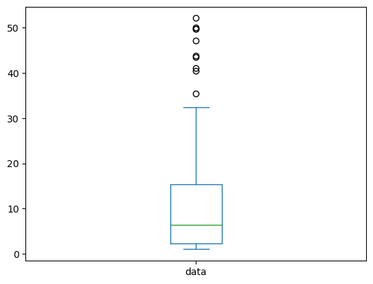

```python
df.plot.box()
```

### Which to choose?

If I were to choose from the graphs depicted above, I would choose the histogram - with certain provisions.

- The changes I suggest in the formatting changes below would need to be instituted
- The changes must include:
1. A title which describes the data depicted
2. Axis labels that clearly inform the consumer of what is being graphed
3. a separation of the bins so that it is more clear

### Formatting Change, if any.

I would change the histogram plot code to include

- The title for the plot
- Descriptive labels for the x and y axes
- Either a legend that describes the data being displayed, or no legend at all
- Data labels would help, especially in this context

```
The 75th percentile of all drug costs is: $15.46
which means that 75% of the drug costs are below this value and 25% are above it.
```

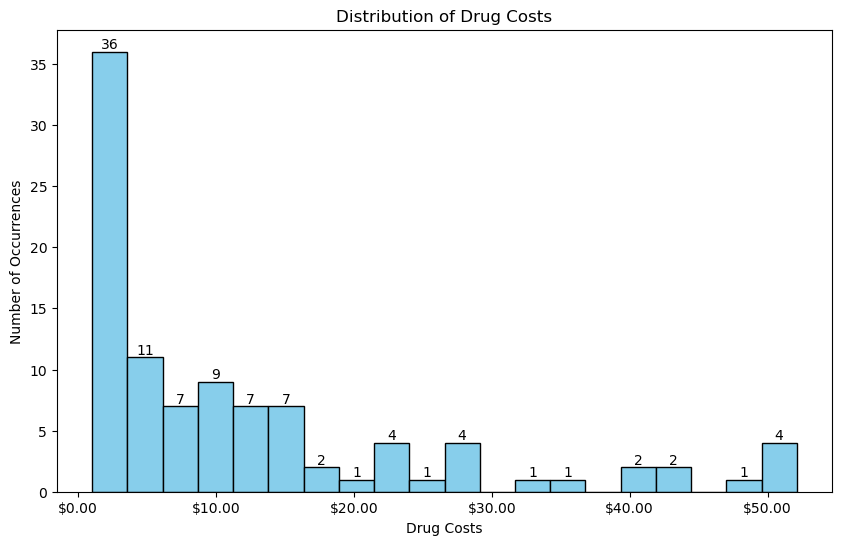

```python
# I import FuncFormatter from matplotlib.ticker to format the x-axis of the histogram to display drug costs in a more readable format (e.g., with a dollar sign and 2 decimal places).
from matplotlib.ticker import FuncFormatter
# in the print statement, one immediately wants to know what it means. I also added a dollar sig and rounded the value to 2 decimal places for better readability.
print(f"The 75th percentile of all drug costs is: ${round(df.quantile(q = 0.75).item(), 2):.2f}")
print("which means that 75% of the drug costs are below this value and 25% are above it.")
# the plot has been changed to include some styling and labels to make it more informative and visually appealing.

ax = df.plot.hist(legend = False, bins = 20, figsize = (10, 6), color = "skyblue", edgecolor = "black", title = "Distribution of Drug Costs", xlabel = "Drug Costs", ylabel = "Number of Occurrences")
ax.xaxis.set_major_formatter(FuncFormatter(lambda x, p: f'${x:.2f}'))

# code to add data labels on top of each bar
for p in ax.patches:
    height = p.get_height()
    if height > 0:
        ax.text(p.get_x() + p.get_width()/2., height,
                f'{int(height)}',
                ha='center', va='bottom')
```

# 3. Homework - working on your datasets

This week, you will do the same types of exercises as last week, but you should use your chosen datasets that someone in your class found last semester. (They likely will not be the particular datasets that you found yourself.)

### Here are some types of analysis you can do:

#### Read in dataframe

```python
dcd25 = pd.read_csv("..\dcd_2025.tsv", sep = "\t")
dcd25_copy = dcd25.copy()
```

#### Functions

```python
def find_missing(df):
    missing_summary = pd.DataFrame({
    'Column': df.columns,
    'Missing_Count': df.isnull().sum().values,
    'Missing_Percent': (df.isnull().sum() / len(df) * 100).values
    })
    missing_summary = missing_summary.sort_values('Missing_Percent', ascending=False)
    print(missing_summary)

    return missing_summary
```

```python
def show_missing_columns(df, lower_bound, upper_bound):
    missing_percent = (df.isnull().sum() / len(df)) * 100
    filtered_missing = missing_percent[(missing_percent > lower_bound) & (missing_percent <= upper_bound)]
    count = len(filtered_missing)

    # Generate markdown table
    table_df = filtered_missing.reset_index()
    table_df.columns = ['Column', 'Missing %']
    table_df['Missing %'] = table_df['Missing %'].round(2)
    print(f"Count: \033[1m{count}\033[0m columns with missing values between {lower_bound}% and {upper_bound}%:")
    print(table_df.to_markdown(index=False))
    print('\n')

    return filtered_missing, count
```

```python
dcd25summary = find_missing(dcd25)
```

```
         Column  Missing_Count  Missing_Percent
25  Unnamed: 25         171004            100.0
57  Unnamed: 57         171004            100.0
26  Unnamed: 26         171004            100.0
27  Unnamed: 27         171004            100.0
32  Unnamed: 32         171004            100.0
..          ...            ...              ...
9        enroll              0              0.0
13        amind              0              0.0
16         hisp              0              0.0
3    state_name              0              0.0
2      district              0              0.0

[65 rows x 3 columns]
```

```python
dcd25_Percent95, dcd25_percent95_count = show_missing_columns(dcd25, 95, 100)
```

```
Count: 45 columns with missing values between 95% and 100%:
| Column      |   Missing % |
|:------------|------------:|
| Unnamed: 20 |         100 |
| Unnamed: 21 |         100 |
| Unnamed: 22 |         100 |
| Unnamed: 23 |         100 |
| Unnamed: 24 |         100 |
| Unnamed: 25 |         100 |
| Unnamed: 26 |         100 |
| Unnamed: 27 |         100 |
| Unnamed: 28 |         100 |
| Unnamed: 29 |         100 |
| Unnamed: 30 |         100 |
| Unnamed: 31 |         100 |
| Unnamed: 32 |         100 |
| Unnamed: 33 |         100 |
| Unnamed: 34 |         100 |
| Unnamed: 35 |         100 |
| Unnamed: 36 |         100 |
| Unnamed: 37 |         100 |
| Unnamed: 38 |         100 |
| Unnamed: 39 |         100 |
| Unnamed: 40 |         100 |
| Unnamed: 41 |         100 |
| Unnamed: 42 |         100 |
| Unnamed: 43 |         100 |
| Unnamed: 44 |         100 |
| Unnamed: 45 |         100 |
| Unnamed: 46 |         100 |
| Unnamed: 47 |         100 |
| Unnamed: 48 |         100 |
| Unnamed: 49 |         100 |
| Unnamed: 50 |         100 |
| Unnamed: 51 |         100 |
| Unnamed: 52 |         100 |
| Unnamed: 53 |         100 |
| Unnamed: 54 |         100 |
| Unnamed: 55 |         100 |
| Unnamed: 56 |         100 |
| Unnamed: 57 |         100 |
| Unnamed: 58 |         100 |
| Unnamed: 59 |         100 |
| Unnamed: 60 |         100 |
| Unnamed: 61 |         100 |
| Unnamed: 62 |         100 |
| Unnamed: 63 |         100 |
| Unnamed: 64 |         100 |
```

```python
dcd25_new = dcd25.drop(columns=dcd25_Percent95.index.tolist())
dcd25_new.sample(10)
```

|  | year | leaid | district | state_name | stabbr | ppcstot | predcost | fundinggap | outcomegap | enroll | pov | iep | ell | amind | asian | black | hisp | multi | pac | white |
| --- | --- | --- | --- | --- | --- | --- | --- | --- | --- | --- | --- | --- | --- | --- | --- | --- | --- | --- | --- | --- |
| 52162 | 2018 | 2506210 | HOLLAND | Massachusetts | MA | 14506 | 10201 | 4305 | 0.333234 | 233 | 0.106599 | 0.150215 | 0.002297 | 0.004292 | 0.017167 | 0.021459 | 0.051502 | 0.004292 | 0.000000 | 0.901288 |
| 100044 | 2014 | 1924960 | RUDD-ROCKFORD-MARBLE RK COMM SCHOOL DISTRICT | Iowa | IA | 10825 | 9507 | 1318 | -0.100329 | 475 | 0.110039 | 0.124211 | 0.000000 | 0.006289 | 0.000000 | 0.029350 | 0.014675 | 0.008386 | 0.000000 | 0.941300 |
| 45406 | 2019 | 4218390 | PALMYRA AREA SD | Pennsylvania | PA | 11540 | 7661 | 3879 | 0.561822 | 3618 | 0.068598 | 0.189331 | 0.010503 | 0.000829 | 0.034273 | 0.011056 | 0.061913 | 0.037590 | 0.000829 | 0.853510 |
| 147966 | 2010 | 1302550 | GWINNETT COUNTY | Georgia | GA | 9278 | 11514 | -2236 | 0.165882 | 159296 | 0.175613 | 0.108534 | 0.129344 | 0.004639 | 0.101321 | 0.274696 | 0.251695 | 0.039078 | 0.001243 | 0.327328 |
| 120089 | 2013 | 4843860 | VALLEY VIEW ISD | Texas | TX | 7948 | 10387 | -2439 | 0.105248 | 698 | 0.174157 | 0.101719 | 0.051576 | 0.004298 | 0.012894 | 0.000000 | 0.180516 | 0.021490 | 0.000000 | 0.780802 |
| 154116 | 2010 | 3805160 | DIVIDE COUNTY 1 | North Dakota | ND | 14654 | 9826 | 4828 | 0.075045 | 234 | 0.147186 | 0.111111 | 0.000000 | 0.008547 | 0.004274 | 0.000000 | 0.017094 | NaN | NaN | 0.970085 |
| 72602 | 2016 | 601860 | ALBANY CITY UNIFIED | California | CA | 12572 | 9338 | 3234 | 0.649450 | 3822 | 0.067884 | 0.085557 | 0.158817 | 0.001310 | 0.292300 | 0.036668 | 0.162651 | 0.131483 | 0.002095 | 0.373494 |
| 127681 | 2012 | 3100018 | WAUNETA-PALISADE PUBLIC SCHS | Nebraska | NE | 16651 | 13062 | 3589 | NaN | 212 | 0.209524 | 0.165094 | 0.014151 | 0.009434 | 0.009434 | 0.000000 | 0.047170 | 0.009434 | 0.000000 | 0.924528 |
| 64207 | 2017 | 2505280 | GLOUCESTER | Massachusetts | MA | 17395 | 10450 | 6945 | 0.239930 | 2983 | 0.108088 | 0.243379 | 0.049279 | 0.003413 | 0.014335 | 0.016723 | 0.080546 | 0.027304 | 0.002730 | 0.854949 |
| 84641 | 2015 | 502250 | ALMA SCHOOL DISTRICT | Arkansas | AR | 8846 | 8599 | 247 | -0.175529 | 3221 | 0.191368 | 0.122943 | 0.001863 | 0.012729 | 0.003726 | 0.013971 | 0.038808 | 0.037255 | 0.000931 | 0.892580 |

```python
# rename columns in dcd25_new for clarity
dcd25_renamed = dcd25_new.rename(columns={'predcost': 'req_spending', 'ppcstot': 'actual_spending', 'ell': 'per_eng_learn', 'leaid': 'district_id', 'iep': 'per_speced', 'fundinggap': 'req_actual_diff', 'outcomegap': 'testscore_gap', 'amind': 'per_amerindian', 'asian': 'per_asian', 'black': 'per_black', 'hisp': 'per_hispanic', 'white': 'per_white', 'multi': 'per_multi', 'pac': 'per_pac_hi'})
dcd25_renamed.sample(10)
```

|  | year | district_id | district | state_name | stabbr | actual_spending | req_spending | req_actual_diff | testscore_gap | enroll | pov | per_speced | per_eng_learn | per_amerindian | per_asian | per_black | per_hispanic | per_multi | per_pac_hi | per_white |
| --- | --- | --- | --- | --- | --- | --- | --- | --- | --- | --- | --- | --- | --- | --- | --- | --- | --- | --- | --- | --- |
| 162575 | 2009 | 2200180 | BEAUREGARD PARISH | Louisiana | LA | 9114 | 8259 | 855 | -0.167797 | 5959 | 0.172378 | 0.153717 | 0.001846 | 0.009062 | 0.009062 | 0.164625 | 0.019802 | NaN | NaN | 0.797449 |
| 14214 | 2021 | 1713370 | EDGAR COUNTY CUD 6 | Illinois | IL | 16240 | 19232 | -2992 | NaN | 288 | 0.155477 | NaN | 0.001291 | 0.000000 | 0.006944 | 0.006944 | 0.010417 | 0.031250 | 0.000000 | 0.944444 |
| 121262 | 2013 | 5602830 | FREMONT COUNTY SCHOOL DISTRICT # 6 | Wyoming | WY | 21446 | 9317 | 12129 | 0.153994 | 388 | 0.112412 | 0.131443 | 0.012887 | 0.208763 | 0.000000 | 0.002577 | 0.028351 | 0.061856 | 0.005155 | 0.693299 |
| 153820 | 2010 | 3625020 | ROSCOE CENTRAL SCHOOL DISTRICT | New York | NY | 27520 | 9947 | 17573 | -0.076106 | 248 | 0.118280 | 0.149194 | 0.000000 | 0.000000 | 0.004032 | 0.016129 | 0.064516 | NaN | NaN | 0.915323 |
| 57644 | 2018 | 4400420 | FOSTER-GLOCESTER | Rhode Island | RI | 17337 | 8938 | 8399 | NaN | 1257 | 0.083213 | 0.096261 | 0.001081 | 0.002396 | 0.013578 | 0.005591 | 0.021566 | 0.015974 | 0.000000 | 0.940894 |
| 161967 | 2009 | 1920100 | MURRAY COMM SCHOOL DISTRICT | Iowa | IA | 9066 | 8605 | 461 | -0.167518 | 319 | 0.145695 | 0.131661 | 0.031348 | 0.000000 | 0.003135 | 0.012539 | 0.040752 | NaN | NaN | 0.943574 |
| 27609 | 2020 | 2011790 | SOUTH HAVEN | Kansas | KS | 15330 | 16057 | -727 | NaN | 209 | 0.182390 | 0.181818 | 0.000000 | 0.000000 | 0.004785 | 0.004785 | 0.009569 | 0.038277 | 0.000000 | 0.942584 |
| 42977 | 2019 | 3604620 | BERLIN CENTRAL SCHOOL DISTRICT | New York | NY | 26103 | 11086 | 15018 | NaN | 709 | 0.129132 | 0.177715 | 0.002510 | 0.000000 | 0.004310 | 0.007184 | 0.005747 | 0.021552 | 0.000000 | 0.961207 |
| 25654 | 2020 | 1200960 | JACKSON | Florida | FL | 10204 | 15132 | -4928 | NaN | 6390 | 0.275966 | 0.176056 | 0.011114 | 0.003756 | 0.005008 | 0.303286 | 0.053678 | 0.065571 | 0.000469 | 0.568232 |
| 66910 | 2017 | 3416290 | TRENTON PUBLIC SCHOOL DISTRICT | New Jersey | NJ | 16034 | 23558 | -7524 | -0.598181 | 13637 | 0.328369 | 0.159199 | 0.155019 | 0.000638 | 0.004557 | 0.489519 | 0.486876 | 0.005377 | 0.000638 | 0.012395 |

#### Draw grouped histograms. For instance, if you have tree heights for both maple and oak trees, you could draw histograms for both.

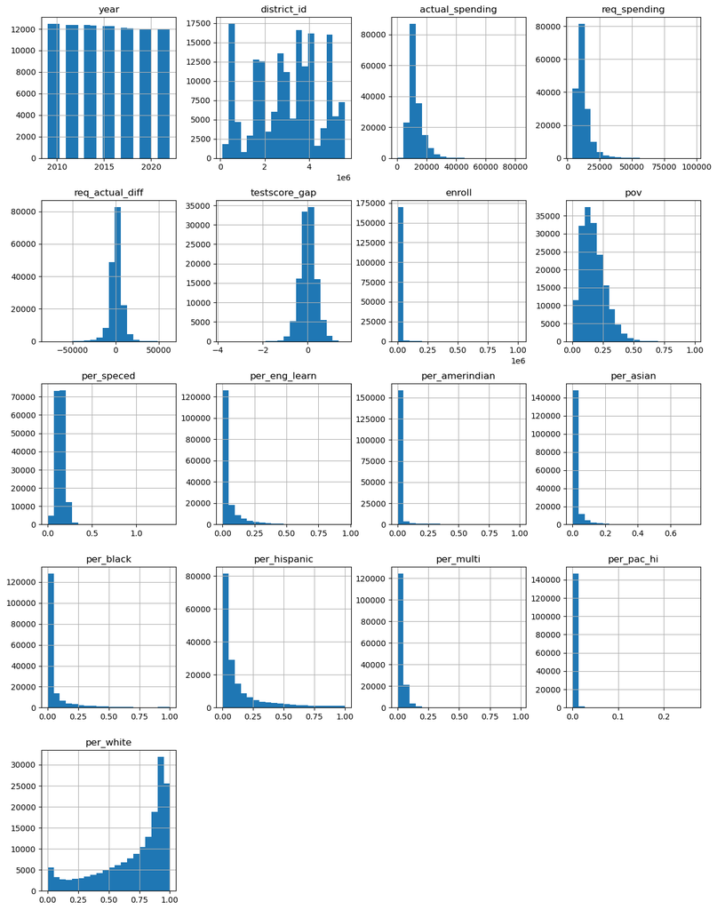

```python
dcd25_renamed.hist(figsize=(15, 20), bins=20);
```

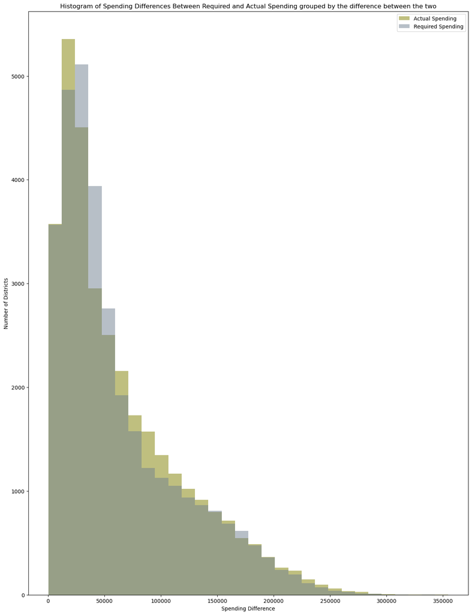

```python
districtID_actual_spending = dcd25_renamed.groupby('req_actual_diff')[['actual_spending', 'req_spending']].sum()
ax = districtID_actual_spending.plot(kind='hist', legend=True, figsize=(15, 20), bins=30, alpha=0.5, xlabel="Spending Difference", ylabel="Number of Districts", title="Histogram of Spending Differences Between Required and Actual Spending grouped by the difference between the two", color=['olive', 'slategray'])
ax.legend(['Actual Spending', 'Required Spending']);
```

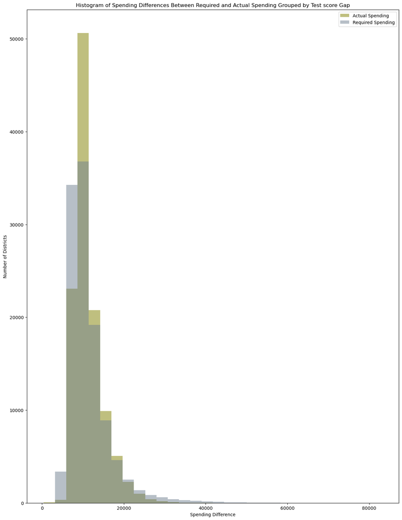

```python
districtID_spending_score_gap = dcd25_renamed.groupby('testscore_gap')[['actual_spending', 'req_spending']].sum()
ax = districtID_spending_score_gap.plot(kind='hist', legend=True, figsize=(15, 20), bins=30, alpha=0.5, xlabel="Spending Difference", ylabel="Number of Districts", title="Histogram of Spending Differences Between Required and Actual Spending Grouped by Test score Gap", color=['olive', 'slategray'])
ax.legend(['Actual Spending', 'Required Spending']);
```

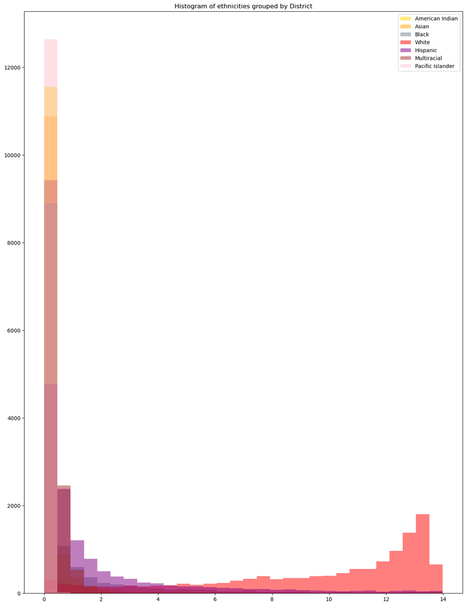

```python
districtID_origin = dcd25_renamed.groupby('district_id')[['per_amerindian', 'per_asian','per_black','per_white', 'per_hispanic','per_multi','per_pac_hi']].sum()
ax = districtID_origin.plot(kind='hist', legend=True, figsize=(15, 20), bins=30, alpha=0.5, xlabel="", ylabel="", title="Histogram of ethnicities grouped by District", color=['gold', 'orange', 'slategray', 'red', 'purple', 'brown', 'pink'])
ax.legend(['American Indian', 'Asian', 'Black', 'White', 'Hispanic', 'Multiracial', 'Pacific Islander']);
```

#### Draw a bar plot to indicate total counts of each categorical variable in a given column.

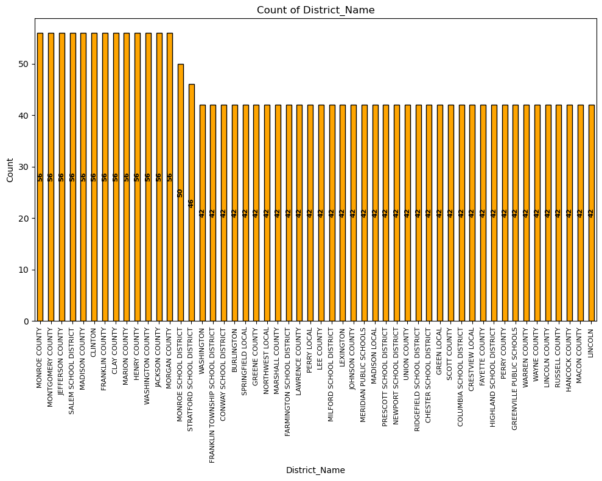

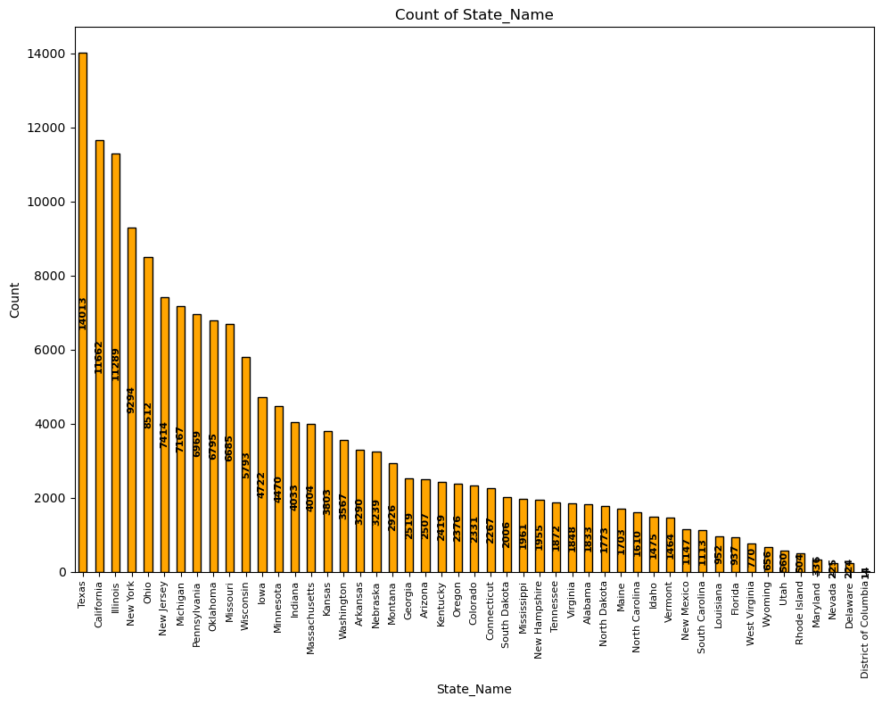

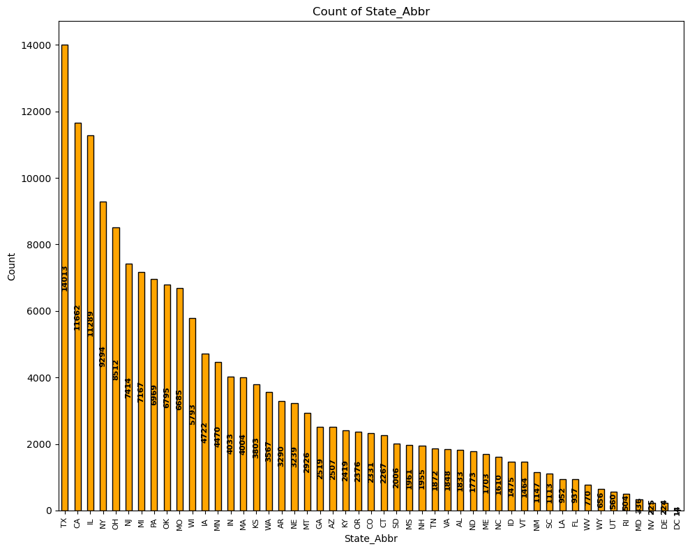

```python
# Bar plot of count of each categorical value
dcd25_rename2 = dcd25.rename(columns={'stabbr': 'State_Abbr', 'state_name': 'State_Name', 'district': 'District_Name'})
categorical_columns = dcd25_rename2.select_dtypes(include=['object', 'category']).columns.tolist()

columns_to_show = 52   # Number of top categories to show in the bar plot

if not categorical_columns:
    print("No categorical columns found in the dataframe.")
else:
    for col in categorical_columns:
        counts = dcd25_rename2[col].value_counts(dropna=False).head(columns_to_show)
        ax = counts.plot(kind='bar', figsize=(10, 8), color='orange', edgecolor='black')
        ax.set_title(f'Count of {col}')
        ax.set_xlabel(col)
        ax.set_ylabel('Count')
        ax.tick_params(axis='x', labelrotation=90, labelsize=8)

        # Add count labels inside bars
        for p in ax.patches:
            height = p.get_height()
            if height > 0:
                ax.text(p.get_x() + p.get_width()/2., height/2,
                        f'{int(height)}',
                        ha='center', va='center', fontsize=8, weight='bold', rotation=90)

        plt.tight_layout()
        plt.show()
```

I do not believe that for this dataset each of these is useful. The stabbr and state_name features should correspond exacty. Although the district count might have some information - like the nuumber of entries for each district, the sheer number of different districts makes what ever may be useful, much less useful.

NOTE: The only way I found to make the plots readable, was to rotate the x axis labels 90 degrees. I believe this is harder to read than no rotation, but the alternative was completely unreadable.

```python
dcd25_rename2.select_dtypes(include=['object', 'category']).count()
```

```
District_Name    171004
State_Name       171004
State_Abbr       171004
dtype: int64
```

##### one-hot encode the categorical columns

```python
dcd25_encoded = pd.get_dummies(dcd25_renamed, drop_first=True)
dcd25_encoded.sample(10)
```

|  | year | district_id | actual_spending | req_spending | req_actual_diff | testscore_gap | enroll | pov | per_speced | per_eng_learn | ... | stabbr_SD | stabbr_TN | stabbr_TX | stabbr_UT | stabbr_VA | stabbr_VT | stabbr_WA | stabbr_WI | stabbr_WV | stabbr_WY |
| --- | --- | --- | --- | --- | --- | --- | --- | --- | --- | --- | --- | --- | --- | --- | --- | --- | --- | --- | --- | --- | --- |
| 130024 | 2012 | 4004110 | 6991 | 11424 | -4433 | 0.317608 | 1644 | 0.262895 | 0.164842 | 0.060827 | ... | False | False | False | False | False | False | False | False | False | False |
| 130373 | 2012 | 4027300 | 6462 | 9594 | -3132 | -0.196876 | 1845 | 0.286145 | 0.146884 | 0.003252 | ... | False | False | False | False | False | False | False | False | False | False |
| 154799 | 2010 | 3904505 | 9801 | 9749 | 52 | -0.153132 | 3697 | 0.236991 | 0.149581 | 0.043819 | ... | False | False | False | False | False | False | False | False | False | False |
| 141528 | 2011 | 3631950 | 15053 | 8173 | 6880 | 0.003542 | 808 | 0.122286 | 0.139851 | 0.004951 | ... | False | False | False | False | False | False | False | False | False | False |
| 62875 | 2017 | 1802440 | 8876 | 12125 | -3249 | 0.217444 | 1631 | 0.224062 | 0.217658 | 0.001839 | ... | False | False | False | False | False | False | False | False | False | False |
| 157084 | 2010 | 4834020 | 11074 | 11487 | -413 | 0.038497 | 1509 | 0.258042 | 0.072896 | 0.149768 | ... | False | False | True | False | False | False | False | False | False | False |
| 42792 | 2019 | 3416440 | 22812 | 9884 | 12928 | 0.541779 | 436 | 0.020501 | 0.231651 | 0.004228 | ... | False | False | False | False | False | False | False | False | False | False |
| 31471 | 2020 | 3626940 | 20795 | 7499 | 13296 | NaN | 1300 | 0.055844 | 0.096923 | 0.002308 | ... | False | False | False | False | False | False | False | False | False | False |
| 1846 | 2022 | 1302730 | 12464 | 13680 | -1216 | NaN | 3623 | 0.193103 | 0.146288 | 0.024841 | ... | False | False | False | False | False | False | False | False | False | False |
| 50565 | 2018 | 1732550 | 8945 | 7632 | 1313 | 0.776355 | 750 | 0.076596 | 0.150667 | 0.012000 | ... | False | False | False | False | False | False | False | False | False | False |

10 rows × 12375 columns

I do not think that one-hot encoding this data was useful in that the categorical column of district name caused the dataset to enlarge exponentially, without a substantial benefit.

#### Draw other histograms

```python
# drop the state abbreviation and state name columns since they are not needed for analysis
dcd25_dropped = dcd25_renamed.drop(columns=['stabbr', 'state_name'])
```

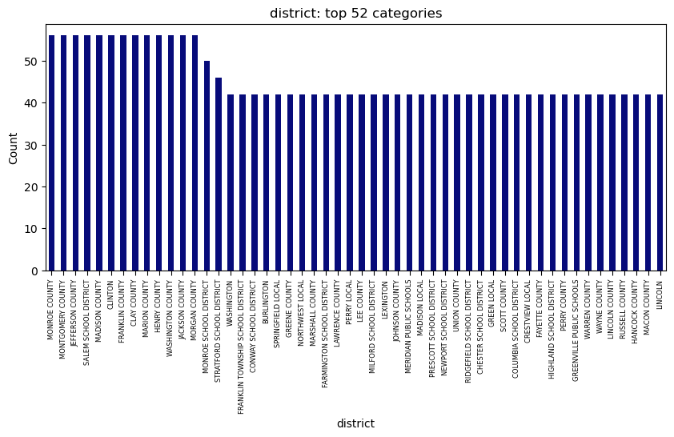

```python
##### creat a bar plot of the categorical columns
categorical_columns = dcd25_dropped.select_dtypes(include=["object", "category"]).columns.tolist()

cols_to_display = 52  # Number of top categories to display in the bar plot

if not categorical_columns:
    print("No categorical columns found in dcd25_dropped.")
else:
    for col in categorical_columns:
        counts = dcd25_dropped[col].value_counts(dropna=False).head(cols_to_display)
        ax = counts.plot(kind="bar", figsize=(10, 4), color="#070B7A")
        ax.set_title(f"{col}: top {cols_to_display} categories")
        ax.set_xlabel(col)
        ax.set_ylabel("Count")
        ax.tick_params(axis="x", labelrotation=90, labelsize=6, size=4)
        categorical_columns = dcd25_dropped[col]
```

#### Mean, Median, and Mode

```python
numeric_columns = dcd25_renamed.select_dtypes(include=['int64', 'float64']).columns.tolist()
mydf_numeric = dcd25_renamed[numeric_columns]
mean = mydf_numeric.mean()
median = mydf_numeric.median()
mode = mydf_numeric.mode()

print(f"Mean:\n{mean}\n")
print(f"Median:\n{median}\n")
print(f"Mode:\n{mode}\n")
```

```
Mean:
year               2.015439e+03
district_id        3.011392e+06
actual_spending    1.252683e+04
req_spending       1.202740e+04
req_actual_diff    4.994371e+02
testscore_gap      2.447095e-02
enroll             3.857395e+03
pov                1.708866e-01
per_speced         1.441290e-01
per_eng_learn      4.809390e-02
per_amerindian     2.550963e-02
per_asian          2.147657e-02
per_black          7.219268e-02
per_hispanic       1.438811e-01
per_multi          3.048377e-02
per_pac_hi         1.437527e-03
per_white          7.087118e-01
dtype: float64

Median:
year               2.015000e+03
district_id        3.028770e+06
actual_spending    1.116900e+04
req_spending       1.062600e+04
req_actual_diff    5.045000e+02
testscore_gap      2.577431e-02
enroll             1.267000e+03
pov                1.561093e-01
per_speced         1.407045e-01
per_eng_learn      1.277370e-02
per_amerindian     2.457000e-03
per_asian          6.649600e-03
per_black          1.384875e-02
per_hispanic       5.454550e-02
per_multi          2.236420e-02
per_pac_hi         1.777000e-04
per_white          8.159819e-01
dtype: float64

```

[output cut: 39 more lines]

```

       per_pac_hi  per_white
0             0.0        1.0
1             NaN        NaN
2             NaN        NaN
3             NaN        NaN
4             NaN        NaN
...           ...        ...
11628         NaN        NaN
11629         NaN        NaN
11630         NaN        NaN
11631         NaN        NaN
11632         NaN        NaN

[11633 rows x 17 columns]
```

### CONCLUSIONS

#### Explain what conclusions you would draw from this analysis: are the data what you expect? Are the data likely to be usable? If they are not useable, find some new data!

Conclusions: The data represent a system that has some significant inadequacies. Although the data is, by and large, what I had expected, it was also demoralizing. The data itself is useful.

#### What is the overall shape of the distribution? Is it normal, skewed, bimodal, uniform, etc.?

```python
dcd25_renamed.shape
```

```
(171004, 20)
```

```python
# The distributions are predominantly right-skewed and not normal. The racial demographics and enrollment are particularly skewed.
```

#### Are there any outliers present? (Data points that are far from the others.)

```python
# find outliers in the numeric columns using IQR method
Q1 = mydf_numeric.quantile(0.25)
Q3 = mydf_numeric.quantile(0.75)
IQR = Q3 - Q1
outliers = ((mydf_numeric < (Q1 - 1.5 * IQR)) | (mydf_numeric > (Q3 + 1.5 * IQR))).sum()
print(f"Number of outliers in each numeric column:\n{outliers}")
```

```
Number of outliers in each numeric column:
year                   0
district_id            0
actual_spending     8531
req_spending        9434
req_actual_diff    12197
testscore_gap       2292
enroll             17748
pov                 2713
per_speced          3784
per_eng_learn      20093
per_amerindian     23105
per_asian          21496
per_black          26151
per_hispanic       20460
per_multi           7755
per_pac_hi         14959
per_white              0
dtype: int64
```

#### If there are multiple related histograms, how does the distribution change across different groups?

#### What are the minimum and maximum values represented in each histogram?

```python
# iterate through the dataset printing out the minimum and maximum values of each numeric feature
for col in numeric_columns:
    col_min = dcd25_renamed[col].min()
    col_max = dcd25_renamed[col].max()
    feature = col.replace('_', ' ').title()  # Convert column name to a more readable
    feature = feature.replace('Per ', 'Percentage of ').replace('Req ', 'Required ').replace('Actual ', 'Actual ').replace('Diff', 'Difference').replace('Gap', 'Gap').replace('Pov', 'Poverty').replace('Eng Learn', 'English Learner Students').replace('Speced', 'Special Education Students').replace('Amerindian', 'American Indian Students').replace('Asian', 'Asian Students').replace('Black', 'Black Students').replace('White', ' White Students').replace('Hispanic', 'Hispanic Students').replace('Multi', 'Multiracial Students').replace('Pac Hi', 'Pacific Islander \ Hawaiian Students')
    print(f"{feature}:     min = {col_min},     max = {col_max}")
```

```
Year:     min = 2009,     max = 2022
District Id:     min = 100005,     max = 5606240
Actual Spending:     min = 251,     max = 83114
Required Spending:     min = 3802,     max = 98479
Required Actual Difference:     min = -78683,     max = 62435
Testscore Gap:     min = -3.7977975,     max = 1.6575414
Enroll:     min = 100,     max = 1014020
Poverty:     min = 0.0,     max = 1.0
Percentage of Special Education Students:     min = 0.0,     max = 1.379532
Percentage of English Learner Students:     min = 0.0,     max = 0.9567404
Percentage of American Indian Students:     min = 0.0,     max = 1.0
Percentage of Asian Students:     min = 0.0,     max = 0.7474986
Percentage of Black Students:     min = 0.0,     max = 1.0
Percentage of Hispanic Students:     min = 0.0,     max = 1.0
Percentage of Multiracial Students:     min = 0.0,     max = 0.9902912
Percentage of Pacific Islander \ Hawaiian Students:     min = 0.0,     max = 0.2674961
Percentage of  White Students:     min = 0.0,     max = 1.0
```

#### How do bin sizes affect the histogram? Does changing the bin width reveal different patterns in the data?

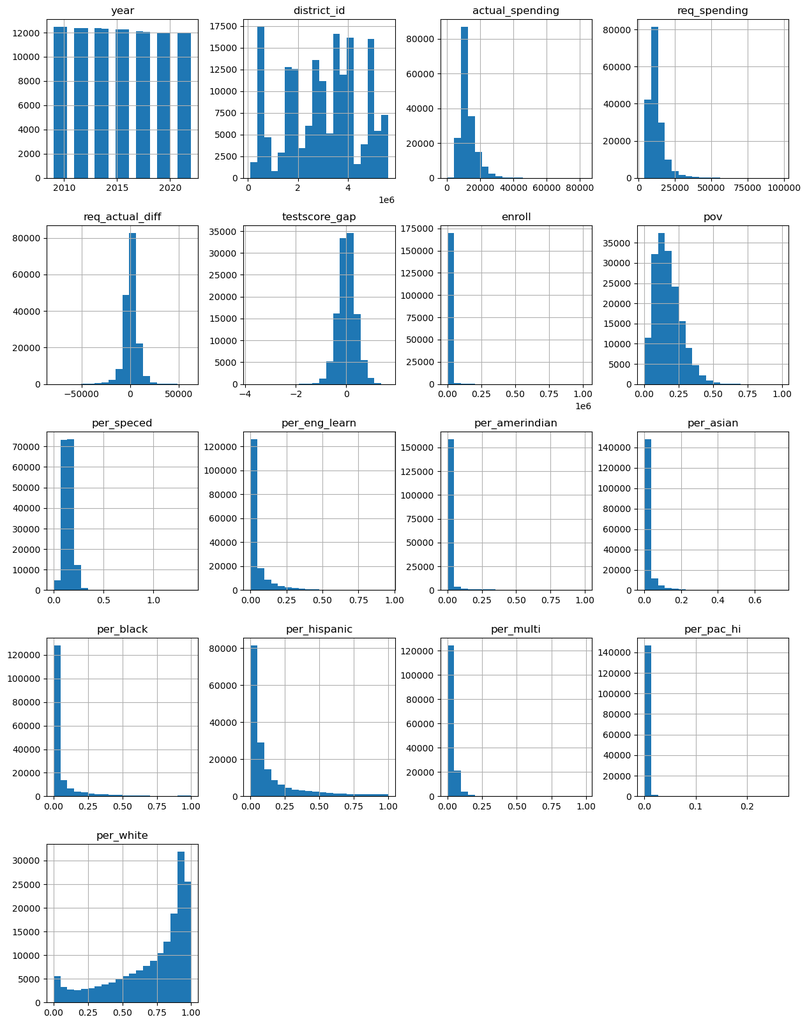

```python
dcd25_renamed.hist(figsize=(15, 20), bins=20);
```

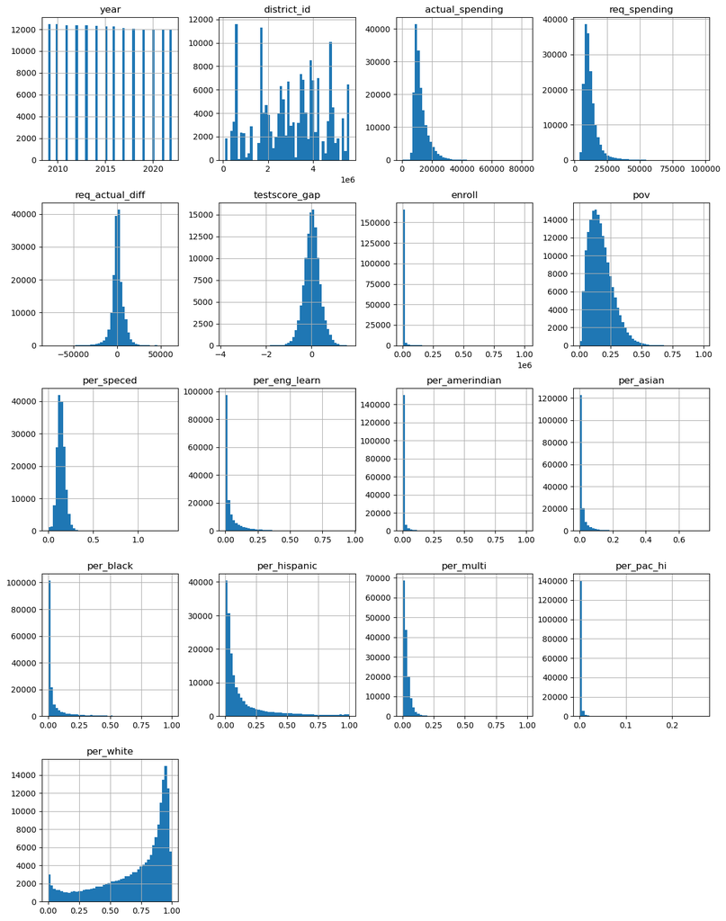

```python
dcd25_renamed.hist(figsize=(15, 20), bins=50);
```

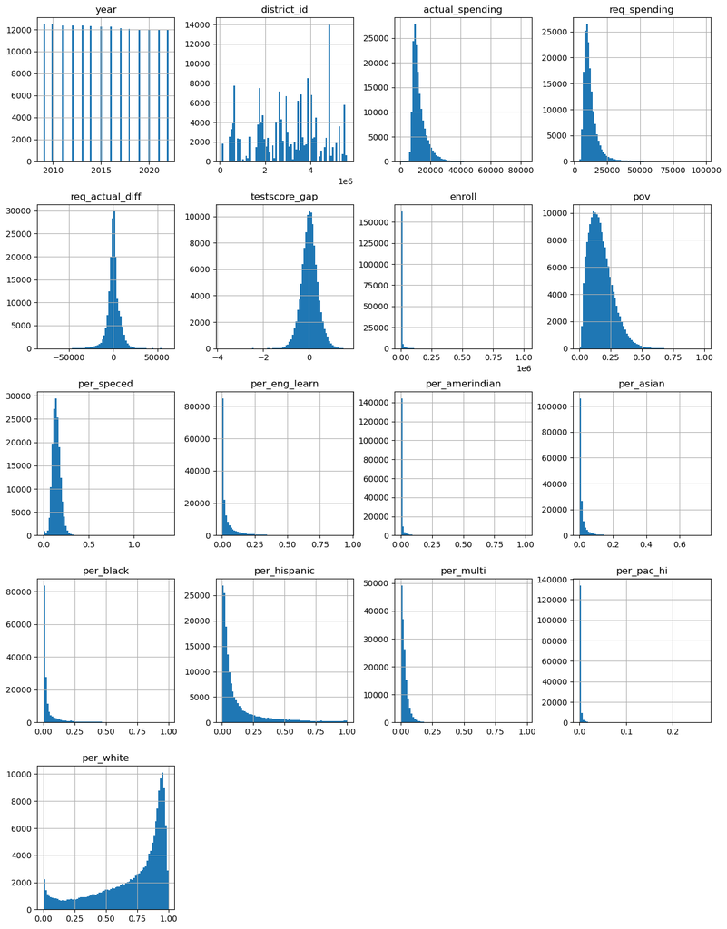

```python
dcd25_renamed.hist(figsize=(15, 20), bins=75);
```

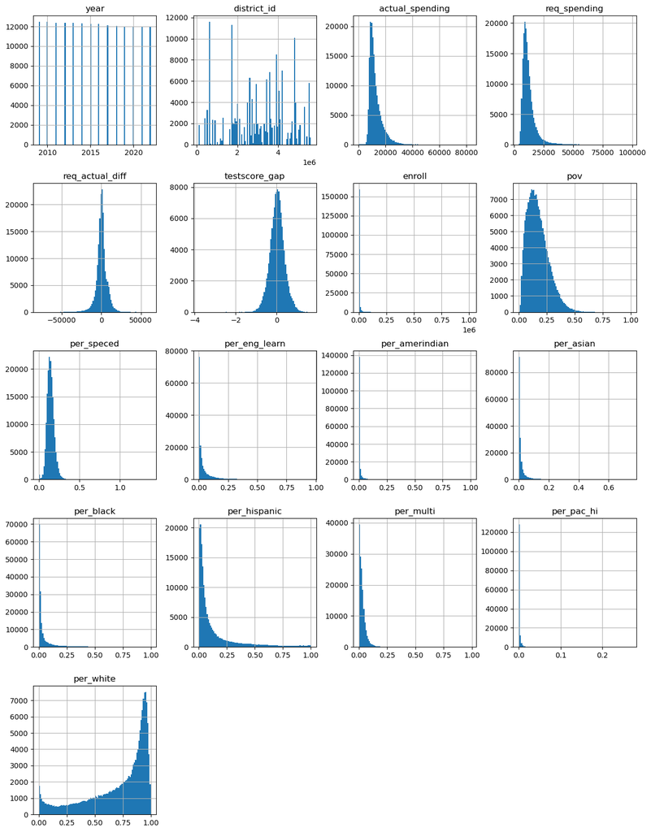

```python
dcd25_renamed.hist(figsize=(15, 20), bins=100);
```

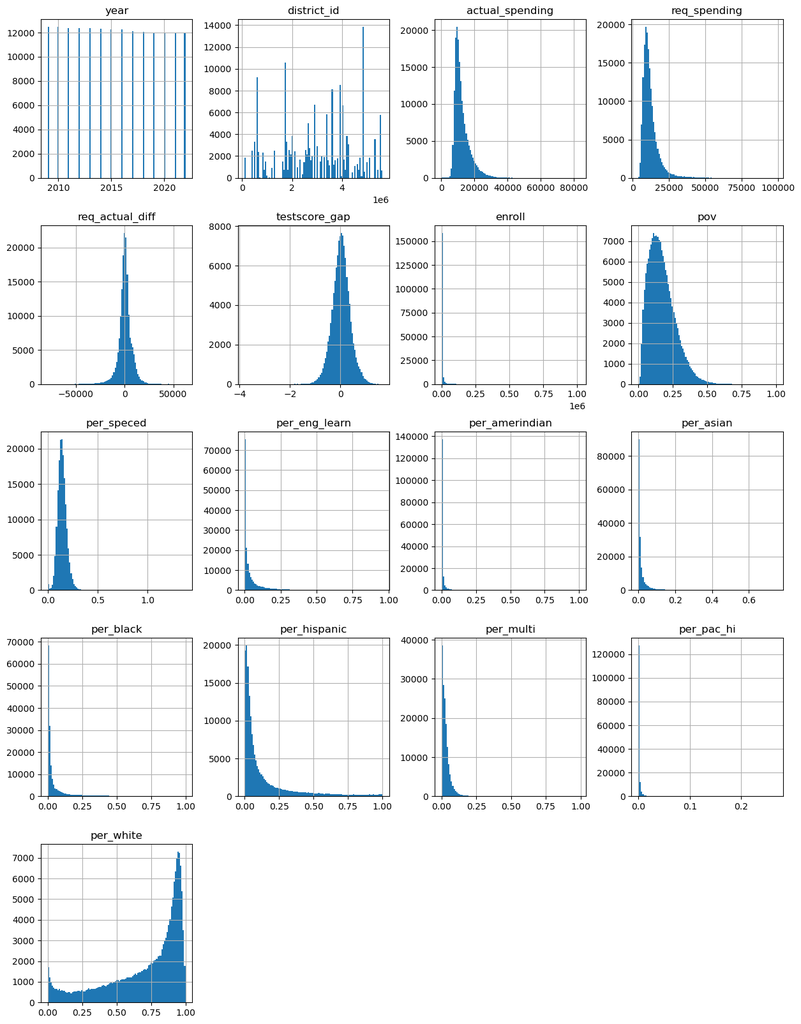

```python
dcd25_renamed.hist(figsize=(15, 20), bins=103);
```

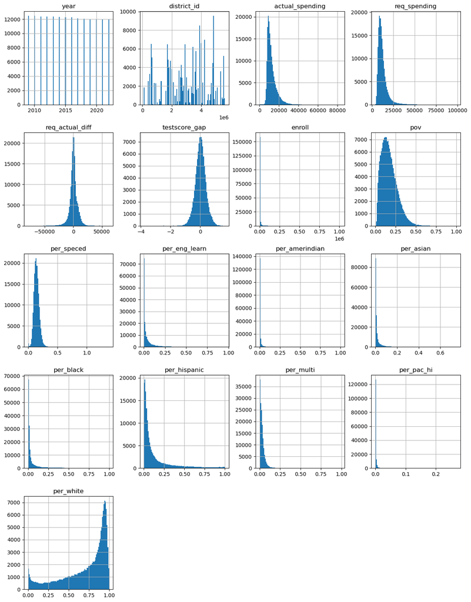

```python
dcd25_renamed.hist(figsize=(15, 20), bins=105);
```

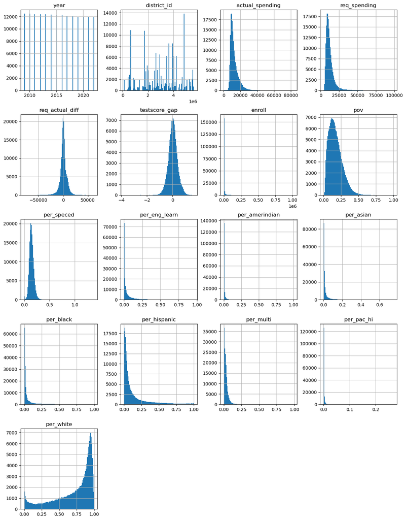

```python
dcd25_renamed.hist(figsize=(15, 20), bins=110);
```

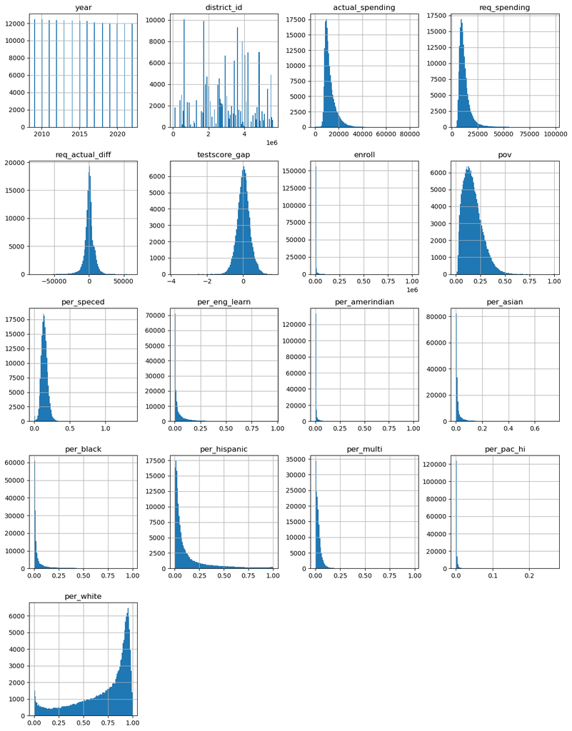

```python
dcd25_renamed.hist(figsize=(15, 20), bins=120);
```

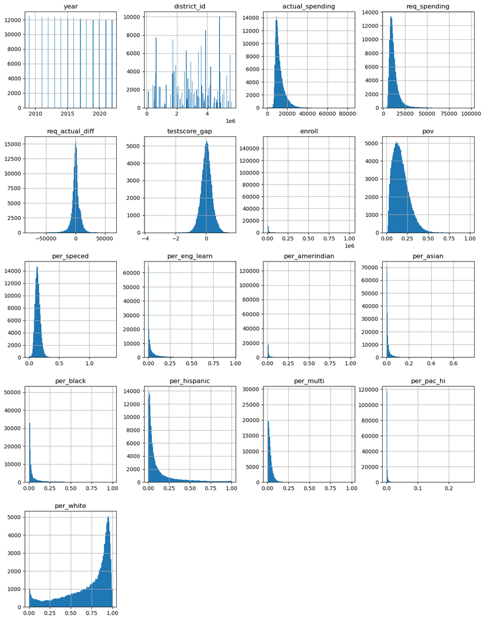

```python
dcd25_renamed.hist(figsize=(15, 20), bins=150);
```

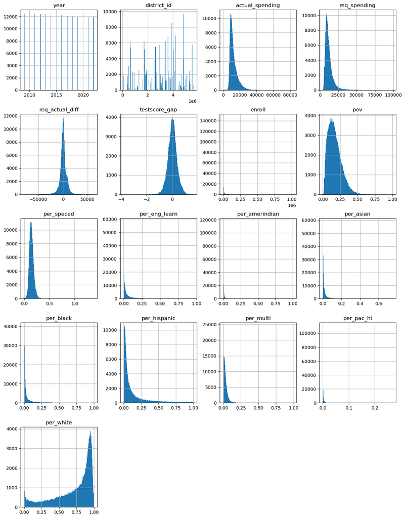

```python
dcd25_renamed.hist(figsize=(15, 20), bins=200);
```

#### Does the distribution appear normal, or does it have a different distribution?

```python
# Check skewness and kurtosis for each numeric column to assess if it is normally distributed or if it has a skewed distribution
print("Distribution Analysis:\n")
print("=" * 80)
for col in dcd25_renamed.select_dtypes(include=['number']).columns:
    skew = dcd25_renamed[col].skew()
    kurt = dcd25_renamed[col].kurtosis()
    print(f"\n{col}:")
    print(f"  Skewness: {skew:.4f} {'(approximately symmetric)' if abs(skew) < 0.5 else '(right-skewed)' if skew > 0 else '(left-skewed)'}")
    print(f"  Kurtosis: {kurt:.4f} {'(approximately normal)' if abs(kurt) < 1 else '(heavy-tailed)' if kurt > 0 else '(light-tailed)'}")

print("\n" + "=" * 80)
print("\nNote: For a normal distribution:")
print("  - Skewness should be close to 0 (between -0.5 and 0.5)")
print("  - Kurtosis should be close to 0 (between -1 and 1)")
```

```
Distribution Analysis:

================================================================================

year:
  Skewness: 0.0198 (approximately symmetric)
  Kurtosis: -1.2103 (light-tailed)

district_id:
  Skewness: -0.1655 (approximately symmetric)
  Kurtosis: -0.9720 (approximately normal)

actual_spending:
  Skewness: 2.0953 (right-skewed)
  Kurtosis: 8.5803 (heavy-tailed)

req_spending:
  Skewness: 2.8622 (right-skewed)
  Kurtosis: 14.7727 (heavy-tailed)

req_actual_diff:
  Skewness: -0.5943 (left-skewed)
  Kurtosis: 6.1489 (heavy-tailed)

testscore_gap:
  Skewness: -0.0434 (approximately symmetric)
  Kurtosis: 0.8615 (approximately normal)

enroll:
  Skewness: 32.6248 (right-skewed)
  Kurtosis: 1707.0579 (heavy-tailed)

pov:
  Skewness: 0.8678 (right-skewed)
  Kurtosis: 0.8382 (approximately normal)

per_speced:
  Skewness: 0.8625 (right-skewed)
  Kurtosis: 7.9881 (heavy-tailed)

```

[output cut: 22 more lines]

```
  Kurtosis: 85.4898 (heavy-tailed)

per_pac_hi:
  Skewness: 15.7775 (right-skewed)
  Kurtosis: 459.4449 (heavy-tailed)

per_white:
  Skewness: -1.0858 (left-skewed)
  Kurtosis: 0.0943 (approximately normal)

================================================================================

Note: For a normal distribution:
  - Skewness should be close to 0 (between -0.5 and 0.5)
  - Kurtosis should be close to 0 (between -1 and 1)
```

##### Heatmap

Although I am not sold on this type of graph for presenting the data, I felt it would be helpful to at least try it out.

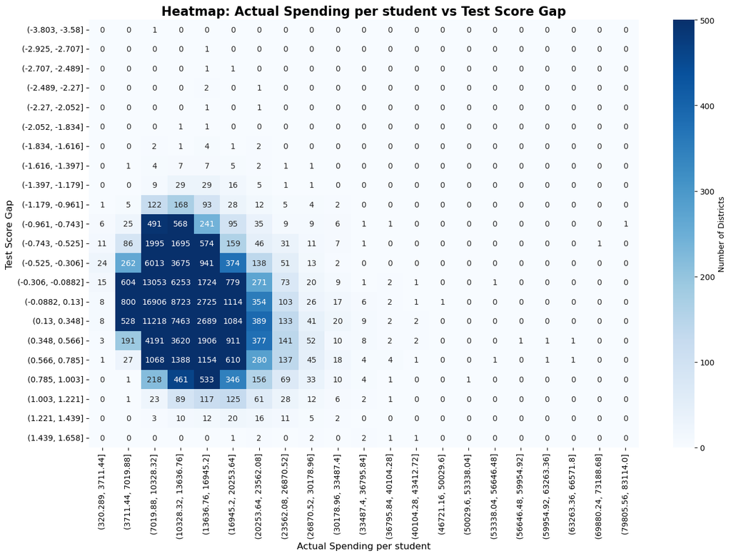

```python
################################################################################
# set initial parameters for the heatmap such as the number of bins for categorizing
# the data, the columns to compare, the titles etc. These parameters will be used
# to create a heatmap that compares the actual spending per student with the test
# score gap across different districts, allowing us to visualize any potential relationships
# or patterns between these two features.

# I set the sample number to 25 to create a heatmap with 25 bins for both the actual
# spending per student and the test score gap. This allows for a detailed comparison
# between the two features while still maintaining a manageable number of categories
# for visualization. By using 25 bins, we can capture the variability in the data and
# identify any patterns or trends that may exist between actual spending and test score gaps
# across different districts.
sample_number = 25
# The first column/feature I want to compare is 'actual_spending', which represents the actual
# amount of money spent per student in each district. This column is crucial for our analysis
# as it allows us to examine how the actual spending correlates with the test score gap, which
# is a key outcome variable in our study. By comparing actual spending with the test score gap,
# we can gain insights into whether higher spending is associated with smaller gaps in test scores,
# which can inform policy decisions and resource allocation in education.
Column_to_compare1 = 'actual_spending'
# set the first title to 'Actual Spending per student' to clearly indicate that the heatmap is comparing
# the actual spending per student across different districts. This title helps to contextualize the data
# and makes it easier for viewers to understand what the heatmap represents, especially when comparing it
# to the second column, which is the test score gap.
title1 = 'Actual Spending per student'
# The second column/feature I want to compare is 'testscore_gap', which represents the gap in test scores
# between different groups of students
Column_to_compare2 = 'testscore_gap'
# The title for the second column is set to 'Test Score Gap' to clearly indicate that we are comparing
# the actual spending per student with the gap in test scores, which is a key outcome variable in our
# analysis. This title helps to contextualize the heatmap and makes it easier for viewers to understand
# what the data represents.
title2 = 'Test Score Gap'
# I use the Set1_r color palette from seaborn to create a visually appealing heatmap that shows the
# relationship between actual spending per student and test score gap across different districts. The
# heatmap will help identify patterns and trends in the data, such as whether higher spending is
# associated with smaller test score gaps.
color_map = sns.color_palette("Blues", as_cmap=True)
# Create a new DataFrame with only the two columns to compare and drop rows with missing values
df = dcd25_renamed[[Column_to_compare1, Column_to_compare2]].dropna()  # Drop rows with missing values in the selected columns
# set the minimum value for the heatmap to 0 to ensure that the color scale starts from zero, which
# allows for a clearer visualization of the differences in the number of districts across the bins
# of actual spending and test score gaps. This helps to highlight areas with higher concentrations
# of districts and makes it easier to interpret the heatmap.
minimum_value = 0
# set the maximum value for the heatmap to 500 to cap the color scale at a reasonable level, which
# prevents extreme values from skewing the visualization and allows for a more meaningful comparison
# of the number of districts across different bins of actual spending and test score gaps. This helps
# to ensure that the heatmap effectively highlights patterns and trends in the data without being
# dominated by outliers.
maximum_value = 500
################################################################################

# Create bins for spending difference and test score gap
feature1 = pd.cut(df[Column_to_compare1], bins=sample_number)
feature2 = pd.cut(df[Column_to_compare2], bins=sample_number)

# Create a pivot table showing the count of districts for each combination
heatmap_data = pd.crosstab(feature2, feature1)

# Create the heatmap
fig, ax = plt.subplots(figsize=(14, 10))
sns.heatmap(heatmap_data, annot=True, fmt='d', cmap=color_map,
            vmin=minimum_value, vmax=maximum_value,
            cbar_kws={'label': 'Number of Districts'}, ax=ax)

# optionally Add legend text
# ax.text(0.9, 1.03, f'Color Scale Range: {minimum_value} - {maximum_value} districts',
#         transform=ax.transAxes, fontsize=10, verticalalignment='top',
#         bbox=dict(boxstyle='round', facecolor='wheat', alpha=0.5))

plt.title(f'Heatmap: {title1} vs {title2}', fontsize=16, fontweight='bold')
plt.xlabel(title1, fontsize=12)
plt.ylabel(title2, fontsize=12)
plt.tight_layout()
plt.show()
plt.close()
```

# 4. Storytelling With Data graph

Reproduce any graph of your choice in p. 52-68 of the Storytelling With Data book as best you can. (The second half of chapter two). You do not have to get the exact data values right, just the overall look and feel.

### Create survey dataframe from data used to create graph in SWD

```python
survey_index = [
    "Survey item A",
    "Survey item B",
    "Survey item C",
    "Survey item D",
    "Survey item E",
]

survey_data = {
    "Strongly Agree": [33, 20, 20, 17, 9],
    "Agree": [27, 28, 15, 23, 18],
    "Neutral": [30, 35, 45, 20, 32],
    "Disagree": [5, 11, 14, 32, 25],
    "Strongly Disagree": [5, 6, 6, 8, 16],
    "Total": [100, 100, 100, 100, 100],
}

survey_df = pd.DataFrame(survey_data, index=survey_index)
survey_df
```

|  | Strongly Agree | Agree | Neutral | Disagree | Strongly Disagree | Total |
| --- | --- | --- | --- | --- | --- | --- |
| Survey item A | 33 | 27 | 30 | 5 | 5 | 100 |
| Survey item B | 20 | 28 | 35 | 11 | 6 | 100 |
| Survey item C | 20 | 15 | 45 | 14 | 6 | 100 |
| Survey item D | 17 | 23 | 20 | 32 | 8 | 100 |
| Survey item E | 9 | 18 | 32 | 25 | 16 | 100 |

### Recreate Graph on page 59

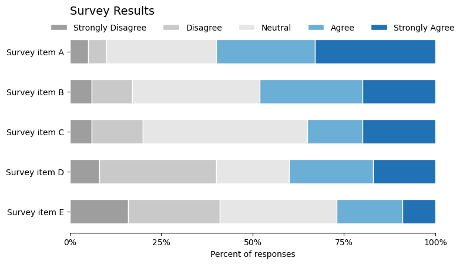

```python
# create the likert titles
likert_order = [
    "Strongly Disagree",
    "Disagree",
    "Neutral",
    "Agree",
    "Strongly Agree",
]

# make a copy of the survey dataframe with only the likert columns
plot_df = survey_df[likert_order].copy()

# set colors for the likert categories
colors = {
    "Strongly Disagree": "#9e9e9e",
    "Disagree": "#c9c9c9",
    "Neutral": "#e6e6e6",
    "Agree": "#6baed6",
    "Strongly Agree": "#2171b5",
}

# create the figure and axis for the plot
fig, ax = plt.subplots(figsize=(8, 4.6))

# Plot stacked bars from left to right (0 to 100)
left = 0
for col in likert_order:
    ax.barh(
        plot_df.index,
        plot_df[col],
        left=left,
        color=colors[col],
        edgecolor="white",
        height=0.6,
        label=col,
    )
    left += plot_df[col]

ax.set_xlim(0, 100)
ax.set_xticks([0, 25, 50, 75, 100])
ax.set_xticklabels(["0%", "25%", "50%", "75%", "100%"])
ax.set_xlabel("Percent of responses")
ax.set_ylabel("")

# set the survey title with padding and font size, aligned to the left
ax.set_title("Survey Results", pad=20, fontsize=14, loc="left")
ax.invert_yaxis()

ax.legend(ncol=5, frameon=False, loc="upper center", bbox_to_anchor=(0.5, 1.07))

ax.spines["top"].set_visible(False)
ax.spines["right"].set_visible(False)
ax.spines["left"].set_visible(False)

plt.tight_layout()
plt.show()
```